# Session 6 - The Layered Grammar of Graphics

Fabian Gülzau

23 November 2017

# Programm

1. Aufgabe: Nobel Prize Data
2. Nobel Prize API
3. Layer in ggplot2
4. Beispiel: Gender und Preise
5. Warum visualisieren?
6. Das Beispiel von Space Shuttle Challenger

# Recap: Aktueller Stand

Aktueller Stand:

- R und RStudio kennengelernt
- Datenaufbereitung mit `dplyr` und `%>%`
  - `arrange`, `select`, `summarize`, `filter`, `mutate`
- Einblick in `ggplot2` als Umsetzung des Grammar of Graphics
- Begründung für die Verwendung von `%>%` und Grammar of Graphics

# Nobel Prize API

- die Daten der Nobelpreisvergabe sind offen [verfügbar](http://api.nobelprize.org/v1/laureate.csv?)
- zudem auf Moodle

# Nobel Prize Data

1. Ladet das Paket `tidyverse` und die Nobelpreis-Daten in R (`read.csv`).
2. Wie viele Beobachtungen und Variablen hat der Datensatz?
3. Über welchen Zeitraum liegen die Daten vor?
4. In welchen Kategorien wird der Nobelpreis vergeben?
5. Gibt es fehlende Werte?

# Elemente des Grammar of Graphics

| Element | Beschreibung |
| --- | --- |
| Daten und Mappings | Daten und Variablen |
| Geometrische Objekte | Darstellung von Data/Mappings |
| Skalen | standard, log, breaks |
| Koordinatensystem | kartesisch, polar, geog. |
| Statistische Transformation | Metrisch -> Kategorial (…) |
| Facets | Small multiples |

# Layers I

Eine Grafik kann aus zwei “layers” bestehen.

Wir haben die Grafik von Minard mit zwei Layers reproduziert. Ein dritter Layer, die Temperatur, haben wir außen vor gelassen.

# Layers II

Layer bestehen immer aus “data, mappings, statistical transformations, and geometric object[s]” (Wickham 2010: 8).

| Element | Beschreibung |
| --- | --- |
| **Daten und Mappings** | Daten und Variablen |
| **Geometrische Objekte** | Darstellung von Data/Mappings |
| Skalen | standard, log, breaks |
| Koordinatensystem | kartesisch, polar, geog. |
| **Statistische Transformation** | Metrisch -> Kategorial (…) |
| Facets | Small multiples |

# Beispiel: Gender und Preise

1. Wie viele Preise wurden über den gesamten Zeitraum hinweg an Männer und Frauen vergeben?
2. Lässt sich dies auch als relative Häufigkeit darstellen?

# Darstellung als Barplot (1 Layer)

Wir können dieses Ergebnis auch grafisch darstellen. Hierbei verwenden wir **einen Layer**:

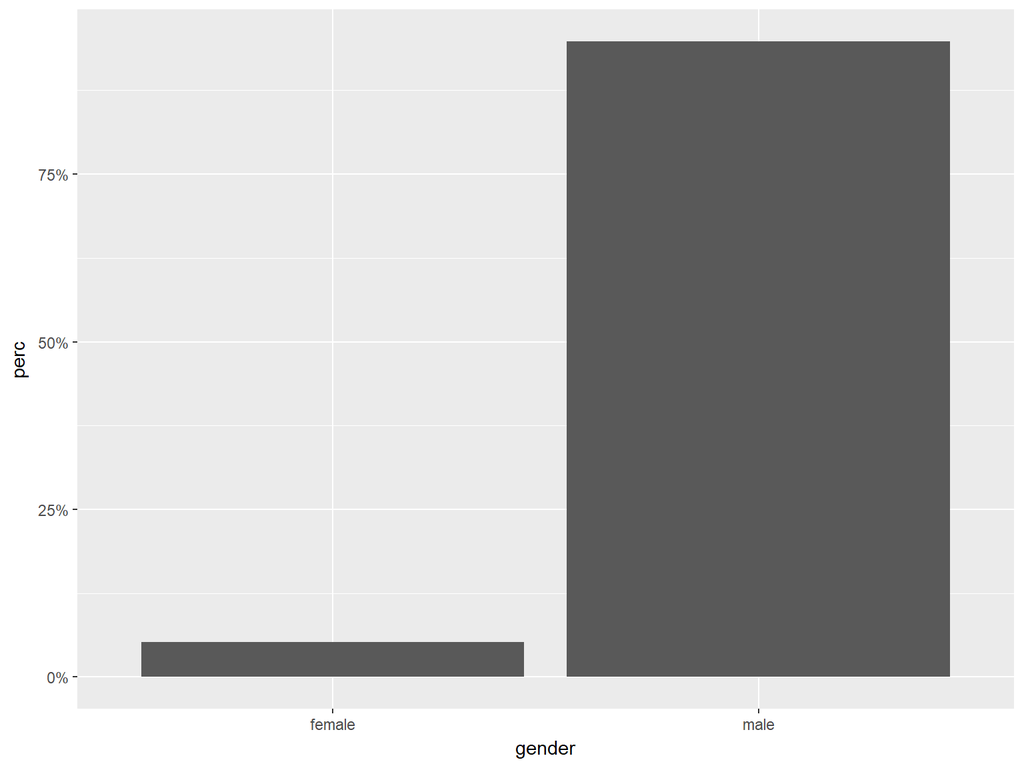

```r
ggplot() +
  geom_bar(data = nobel.perc, mapping = aes(x = gender, y = perc),
           stat = "identity") +
  scale_y_continuous(labels = function(x){paste0(x, "%")})
```

# Zwei Layer I

Eine Fragestellung, die sich aus der drastischen Verteilung von Nobelpreisen zwischen den Geschlechtern ergibt, ist diejenige nach der zeitlichen Verteilung. Hierfür benötigen wir die Verteilung der Preise nach Geschlecht `gender` über die Zeit `year` hinweg.

Das Ergebnis sollte etwa so aussehen:

```r
head(nobel.year)
```

```
## # A tibble: 6 x 3
## # Groups:   year [5]
##    year gender count
##   <int>  <chr> <int>
## 1  1901   male     6
## 2  1902   male     7
## 3  1903 female     1
## 4  1903   male     6
## 5  1904   male     5
## 6  1905 female     1
```

Dies lässt sich so erreichen:

```r
nobel.year <- nobel %>%
  filter(gender != "org" & !is.na(year)) %>%
  group_by(year, gender) %>%
  summarize(count = n())
```

# Zwei Layer II

Wir dieses Ergebnis wieder visualisieren:

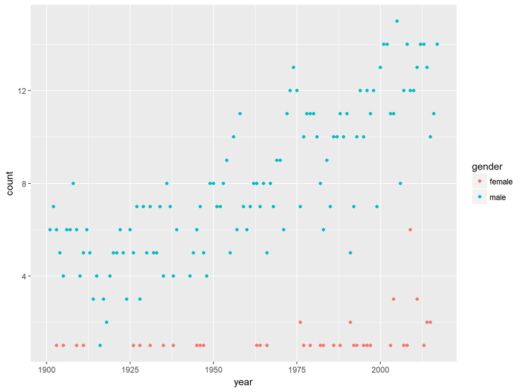

```r
ggplot() +
  geom_point(data = nobel.year,
             mapping = aes(x = year, y = count, color = gender),
             stat = "identity")
```

# Zwei Layer III

Es gibt kein Jahr, in welchem mehr Frauen als Männer den Nobelpreis erhalten haben. Es scheinen aber immer mehr Preise vergeben zu werden.

Liegt dies an neuen Preiskategorien?

```r
nobel %>%
  filter(!is.na(year)) %>%
  group_by(category) %>%
  summarise(first = min(year))
```

```
## # A tibble: 6 x 2
##     category first
##        <chr> <dbl>
## 1  chemistry  1901
## 2  economics  1969
## 3 literature  1901
## 4   medicine  1901
## 5      peace  1901
## 6    physics  1901
```

# Zwei Layer IV

Oder einfach daran, dass mehr Personen gemeinsam einen Preis erhalten?

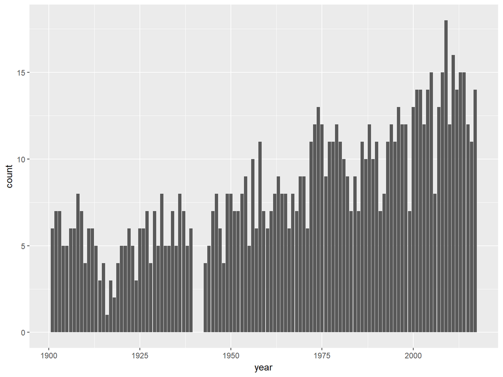

```r
ggplot() +
  geom_bar(data = nobel.year,
           mapping = aes(x = year, y = count),
           stat = "identity")
```

# Zwei Layer VI

Zurück zum Ausgangsplot:

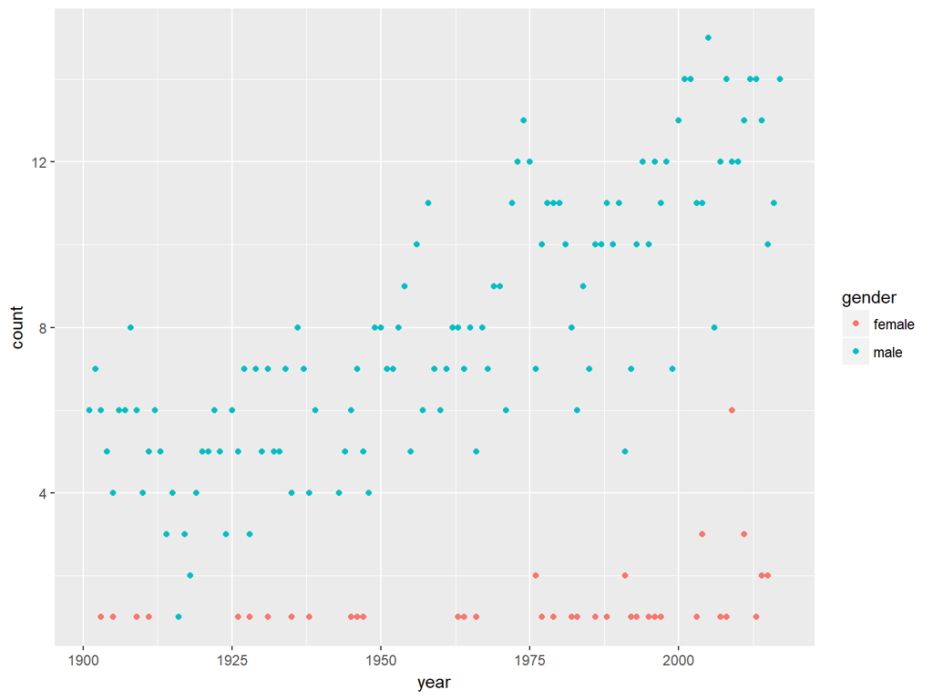

# Zwei Layer VII

Zur besseren Sichtbarkeit könnten wir Regressionslinien zur Zusammenfassung des Trends verwenden (`geom_smooth`).

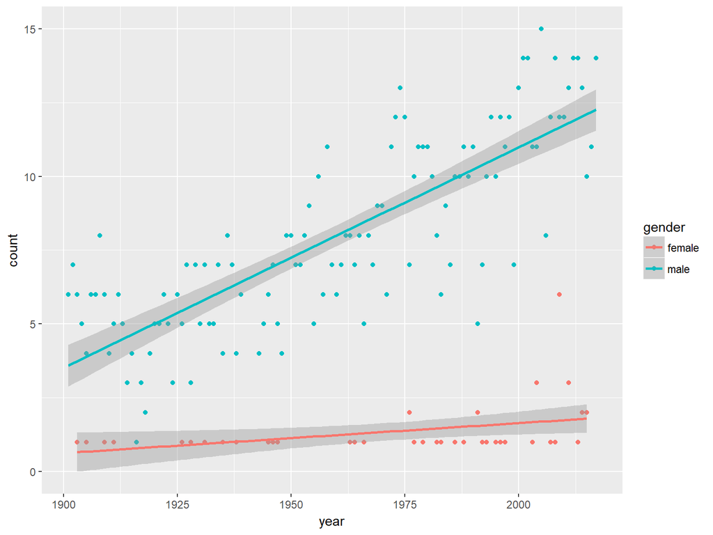